# Create PMML export based on logistic regression model leveraging Framingham heart study data

Alexander Lemm

March 2015

```r
library(pmml)
library(caTools)
library(ROCR)
```

## Read and process data

```r
framingham <- read.csv("./data/framingham.csv")

dim(framingham)
```

```
## [1] 4240   16
```

```r
sum(complete.cases(framingham))
```

```
## [1] 3658
```

```r
framingham <- framingham[complete.cases(framingham), ]
```

What is the accuracy of the baseline model?

```r
tab <- table(framingham$TenYearCHD)
tab
```

```
##
##    0    1
## 3101  557
```

```r
baseline <- tab[1]/sum(tab)
baseline
```

```
##        0
## 0.847731
```

Split the data into training and test set:

```r
set.seed(37)

split <- sample.split(framingham$TenYearCHD, SplitRatio = 0.65)

fram_train <- framingham[which(split), ]
fram_test <- framingham[which(!split), ]
```

## Build logistic regression models and apply them on training set

## First model

Build model including all available independent variables:

```r
fram_log_complete <- glm(TenYearCHD ~ ., family = binomial, data = fram_train)
summary(fram_log_complete)
```

```
##
## Call:
## glm(formula = TenYearCHD ~ ., family = binomial, data = fram_train)
##
## Deviance Residuals:
##     Min       1Q   Median       3Q      Max
## -1.2876  -0.5948  -0.4272  -0.2804   2.8364
##
## Coefficients:
##                   Estimate Std. Error z value Pr(>|z|)
## (Intercept)     -8.8183376  0.9097925  -9.693  < 2e-16 ***
## male             0.5362276  0.1361121   3.940 8.16e-05 ***
## age              0.0662533  0.0083257   7.958 1.75e-15 ***
## education       -0.0291042  0.0605386  -0.481  0.63069
## currentSmoker    0.1052663  0.1954671   0.539  0.59021
## cigsPerDay       0.0156468  0.0077279   2.025  0.04290 *
## BPMeds           0.0739897  0.3026413   0.244  0.80686
## prevalentStroke  0.0606532  0.7055752   0.086  0.93150
## prevalentHyp     0.2491220  0.1702946   1.463  0.14350
## diabetes        -0.1113356  0.4053910  -0.275  0.78359
## totChol          0.0033513  0.0013718   2.443  0.01457 *
## sysBP            0.0145090  0.0046546   3.117  0.00183 **
## diaBP           -0.0076333  0.0077439  -0.986  0.32427
## BMI              0.0110059  0.0152946   0.720  0.47178
## heartRate       -0.0003788  0.0053151  -0.071  0.94319
## glucose          0.0090611  0.0028936   3.131  0.00174 **
## ---
## Signif. codes:  0 '***' 0.001 '**' 0.01 '*' 0.05 '.' 0.1 ' ' 1
##
## (Dispersion parameter for binomial family taken to be 1)
##
##     Null deviance: 2028.7  on 2377  degrees of freedom
## Residual deviance: 1789.2  on 2362  degrees of freedom
## AIC: 1821.2
##
## Number of Fisher Scoring iterations: 5
```

The following variables are significant: `male`, `age`, `cigsPerDay`, `totChol`, `sysBP` and `glucose`.

In addition, we observe an AIC of 1821.1524142.

Next, we evaluate the in-sample accuracy.

```r
predict_train1 <- predict(fram_log_complete, type = "response")
t1_train <- table(fram_train$TenYearCHD, predict_train1 >= 0.5)
t1_train
```

```
##
##     FALSE TRUE
##   0  2008    8
##   1   333   29
```

```r
sum(diag(t1_train))/sum(t1_train)
```

```
## [1] 0.8566022
```

### Second model

Next, we build a second model using some of the significant variables plus those identified as risk factors for corony heart diseases in other studies.

```r
fram_log2 <- glm(TenYearCHD ~ male + age + currentSmoker + totChol + sysBP +
                   glucose, family = 'binomial', data = fram_train)
summary(fram_log2)
```

```
##
## Call:
## glm(formula = TenYearCHD ~ male + age + currentSmoker + totChol +
##     sysBP + glucose, family = "binomial", data = fram_train)
##
## Deviance Residuals:
##     Min       1Q   Median       3Q      Max
## -1.4024  -0.5958  -0.4338  -0.2827   2.7832
##
## Coefficients:
##                Estimate Std. Error z value Pr(>|z|)
## (Intercept)   -9.367899   0.595642 -15.727  < 2e-16 ***
## male           0.602264   0.127889   4.709 2.49e-06 ***
## age            0.066759   0.007934   8.415  < 2e-16 ***
## currentSmoker  0.383345   0.129120   2.969  0.00299 **
## totChol        0.003455   0.001362   2.537  0.01119 *
## sysBP          0.015735   0.002643   5.954 2.61e-09 ***
## glucose        0.008688   0.002148   4.044 5.26e-05 ***
## ---
## Signif. codes:  0 '***' 0.001 '**' 0.01 '*' 0.05 '.' 0.1 ' ' 1
##
## (Dispersion parameter for binomial family taken to be 1)
##
##     Null deviance: 2028.7  on 2377  degrees of freedom
## Residual deviance: 1797.2  on 2371  degrees of freedom
## AIC: 1811.2
##
## Number of Fisher Scoring iterations: 5
```

All independent variables are significant whereas 4 out of 6 are even highly statistically significant. All $\beta$ coefficients show a positive sign.

```r
predict_train2 <- predict(fram_log2, type = "response")

t2_train <- table(fram_train$TenYearCHD, predict_train2 >= 0.5)
t2_train
```

```
##
##     FALSE TRUE
##   0  2002   14
##   1   336   26
```

```r
sum(diag(t2_train))/sum(t2_train)
```

```
## [1] 0.8528175
```

We will only apply the second model on our test set even though the first one possesses a slightly higher in-sample accuracy and a slightly higher AIC.

## Apply final model on test set

```r
predict_test <- predict(fram_log2, type = "response", newdata = fram_test)
summary(predict_test)
```

```
##    Min. 1st Qu.  Median    Mean 3rd Qu.    Max.
## 0.01468 0.06564 0.11490 0.14960 0.20420 0.94190
```

```r
t1_test <- table(fram_test$TenYearCHD, predict_test >= 0.5)
t1_test
```

```
##
##     FALSE TRUE
##   0  1077    8
##   1   185   10
```

```r
acc <- sum(diag(t1_test))/sum(t1_test)
acc
```

```
## [1] 0.8492188
```

The result shows that our logistic regression model (0.8492188) has a slight edge over the baseline model (0.847731) in terms of overall accuracy.

Let’s have a look at the Receiver Operator Characteristic curve:

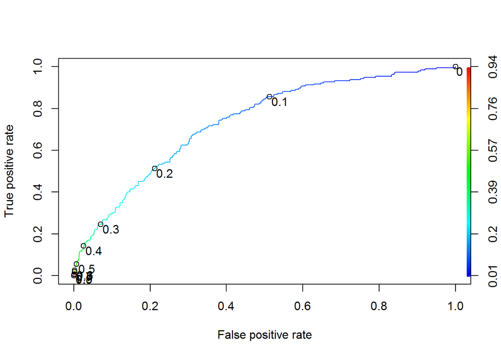

```r
rocr_pred <- prediction(predict_test, fram_test$TenYearCHD)
rocr_perf <- performance(rocr_pred, "tpr", "fpr")
plot(rocr_perf, colorize = TRUE, print.cutoffs.at = seq(0, 1, 0.1),
     text.adj = c(-0.1, 1))
```

What about the AUC?

```r
rocr_auc <- as.numeric(performance(rocr_pred, "auc")@y.values)
rocr_auc
```

```
## [1] 0.7355028
```

## Export PMML file

```r
glm_pmml <- pmml(fram_log2, model.name = "CHD_prediction_model")
xmlFile <- file.path(getwd(),"files/chd_risk_glm.xml")
saveXML(glm_pmml,xmlFile)
```